# Text Mining and Sentiment Analysis

Shaobo Li

We use ABC news data at [Kaggle](https://www.kaggle.com/therohk/million-headlines) to demonstrate text mining and sentiment analysis. There are many good online tutorials and blogs for text mining in R. One of the best textbooks to read is [Text Mining with R](https://www.tidytextmining.com/), which comprehensively illustrates the package `tidytext`, which is a tidy approach for text mining.

### Load ABC News data

```r
library(tidyverse)
library(tidytext)

abcnews <- read_csv("https://www.dropbox.com/s/wucdr914q9kzyd7/abcnews-date-text.csv?dl=1")
abcnews
```

```
## # A tibble: 1,103,663 x 2
##    publish_date headline_text
##           <dbl> <chr>
##  1     20030219 aba decides against community broadcasting licence
##  2     20030219 act fire witnesses must be aware of defamation
##  3     20030219 a g calls for infrastructure protection summit
##  4     20030219 air nz staff in aust strike for pay rise
##  5     20030219 air nz strike to affect australian travellers
##  6     20030219 ambitious olsson wins triple jump
##  7     20030219 antic delighted with record breaking barca
##  8     20030219 aussie qualifier stosur wastes four memphis match
##  9     20030219 aust addresses un security council over iraq
## 10     20030219 australia is locked into war timetable opp
## # ... with 1,103,653 more rows
```

## Basic text mining with `tm` package.

### Corpus

#### Make text data as Corpus

Corpus is a collection of text documents, but we only have one. R package `tm` works only with Corpus.

```r
library(tm)
text<- Corpus(VectorSource(abcnews$headline_text))
```

#### standard cleaning

Typically, we should do some standard cleaning, such as converting everything to lower cases, removing punctuations, and removing words that have no values for the analysis (the so-called “stop words”). Let’s look at what are the existing stop words.

```r
stopwords("english")
```

```
##   [1] "i"          "me"         "my"         "myself"     "we"
##   [6] "our"        "ours"       "ourselves"  "you"        "your"
##  [11] "yours"      "yourself"   "yourselves" "he"         "him"
##  [16] "his"        "himself"    "she"        "her"        "hers"
##  [21] "herself"    "it"         "its"        "itself"     "they"
##  [26] "them"       "their"      "theirs"     "themselves" "what"
##  [31] "which"      "who"        "whom"       "this"       "that"
##  [36] "these"      "those"      "am"         "is"         "are"
##  [41] "was"        "were"       "be"         "been"       "being"
##  [46] "have"       "has"        "had"        "having"     "do"
##  [51] "does"       "did"        "doing"      "would"      "should"
##  [56] "could"      "ought"      "i'm"        "you're"     "he's"
##  [61] "she's"      "it's"       "we're"      "they're"    "i've"
##  [66] "you've"     "we've"      "they've"    "i'd"        "you'd"
##  [71] "he'd"       "she'd"      "we'd"       "they'd"     "i'll"
```

[output cut: 20 more lines]

```r
# some cleaning
text<- tm_map(text, content_transformer(tolower))
text<- tm_map(text, removePunctuation)
text<- tm_map(text, removeWords, stopwords("english"))
```

If you ever want to convert Corpus back to data frame, you may use the lines below. To make word cloud, we don’t necessarily need this.

```r
text.df <- data.frame(text=sapply(text, identity), stringsAsFactors=F)
head(text.df)
```

```
##                                          text
## 1 aba decides  community broadcasting licence
## 2  act fire witnesses must  aware  defamation
## 3   g calls  infrastructure protection summit
## 4         air nz staff  aust strike  pay rise
## 5 air nz strike  affect australian travellers
## 6           ambitious olsson wins triple jump
```

#### Document matrix

For other text analysis and management, it may be useful to build a term-document matrix. This matrix has the form that row names are each different words and column names are simply the document, which is the news headline. You can conver a document matrix to R matrix using `as.matrix()`. This will be a very sparse matrix, and should be very large. We are not able to make it for this data (over 700 GB).

```r
dtm <- TermDocumentMatrix(text)
# as.matrix(dtm)
```

### Word Cloud

Word cloud is a very good data visualization tool for text data. It gives you an overall impression that what a set of documents talk about. It is also a very useful figure for presentation. In R, it is easy to generate the word cloud figure using `wordcloud` package.

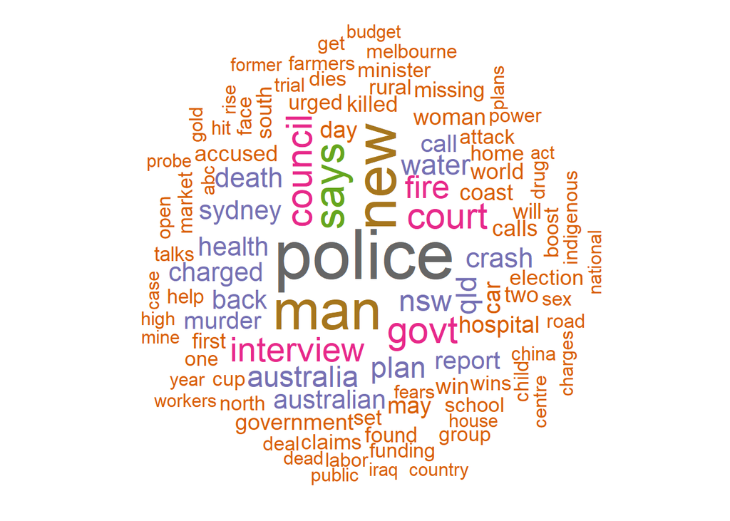

```r
library(wordcloud)
wordcloud(text, max.words = 100, random.order = FALSE, rot.per=0.3, colors=brewer.pal(8, "Dark2"))
```

- `max.words` and `min.freq`: These parameters are used to limit the number of words plotted. max.words will plot the specified number of words and discard least frequent terms, whereas, min.freq will discard all terms whose frequency is below the specified value.
- `random.order`: By setting this to FALSE, we make it so that the words with the highest frequency are plotted first. If we don’t set this, it will plot the words in a random order, and the highest frequency words may not necessarily appear in the center.
- `rot.per`: This value determines the fraction of words that are plotted vertically.
- `colors`: The default value is black. If you want to use different colors based on frequency, you can specify a vector of colors, or use one of the pre-defined color palettes. You can find a list [here](http://www.sthda.com/sthda/RDoc/images/rcolorbrewer.png).

Back to top

## Sentiment analysis

### Sentiment data

We will use a tidy approach based on package `tidytext` to conduct sentiment analysis.

First, there is a important dataset called `sentiments` in this package. This dataset is essentially pre-built sentiment dictionary. Let’s take a look.

```r
sentiments
```

```
## # A tibble: 6,786 x 2
##    word        sentiment
##    <chr>       <chr>
##  1 2-faces     negative
##  2 abnormal    negative
##  3 abolish     negative
##  4 abominable  negative
##  5 abominably  negative
##  6 abominate   negative
##  7 abomination negative
##  8 abort       negative
##  9 aborted     negative
## 10 aborts      negative
## # ... with 6,776 more rows
```

Let’s see how many sentiment categories this data has.

```r
sentiments%>% count(sentiment)
```

```
## # A tibble: 2 x 2
##   sentiment     n
##   <chr>     <int>
## 1 negative   4781
## 2 positive   2005
```

In addition, there are other lexicons contributed by different authors. We can pull these lexicons with `get_sentiments()`, but you need to install a package `textdata` first, and then it will ask you if you want to download the specific lexicon.

```r
get_sentiments("bing")  # this is the same as pre-built data "sentiments"
get_sentiments("nrc")
get_sentiments("afinn")
```

Different lexicon has different sentiment labels. `nrc` is probably the richest one that has 10 different labels, and a word may have multiple sentiment labels.

```r
get_sentiments("nrc")%>% count(sentiment)
```

```
## # A tibble: 10 x 2
##    sentiment        n
##    <chr>        <int>
##  1 anger         1247
##  2 anticipation   839
##  3 disgust       1058
##  4 fear          1476
##  5 joy            689
##  6 negative      3324
##  7 positive      2312
##  8 sadness       1191
##  9 surprise       534
## 10 trust         1231
```

### Sentiment analysis with inner join

#### Restructure the data

The first step is to restructure the data. In other words, we need to split sentences to every single word.

```r
abcnews1<- abcnews %>% unnest_tokens(word, headline_text)
abcnews1
```

```
## # A tibble: 7,070,557 x 2
##    publish_date word
##           <dbl> <chr>
##  1     20030219 aba
##  2     20030219 decides
##  3     20030219 against
##  4     20030219 community
##  5     20030219 broadcasting
##  6     20030219 licence
##  7     20030219 act
##  8     20030219 fire
##  9     20030219 witnesses
## 10     20030219 must
## # ... with 7,070,547 more rows
```

#### Overall sentiment with “nrc” lexicon

In order to know the sentiment category of our document data, we need to join it with the sentiment dataset we saw before. Inner join is commonly used for the joining.

```r
# look at the words belong to "joy" from the sentiment data with nrc lexicon
nrc_joy <- get_sentiments("nrc") %>%
  filter(sentiment == "joy")
nrc_joy
```

```
## # A tibble: 689 x 2
##    word          sentiment
##    <chr>         <chr>
##  1 absolution    joy
##  2 abundance     joy
##  3 abundant      joy
##  4 accolade      joy
##  5 accompaniment joy
##  6 accomplish    joy
##  7 accomplished  joy
##  8 achieve       joy
##  9 achievement   joy
## 10 acrobat       joy
## # ... with 679 more rows
```

```r
# count the words in our data that belong to "joy"
abcnews1 %>%
  inner_join(nrc_joy) %>%
  count(word, sort = TRUE)
```

```
## # A tibble: 602 x 2
##    word      n
##    <chr> <int>
##  1 found  7839
##  2 child  6655
##  3 sex    6582
##  4 labor  6458
##  5 deal   6356
##  6 pay    4885
##  7 green  3761
##  8 vote   3118
##  9 share  3100
## 10 food   2922
## # ... with 592 more rows
```

```r
# Now count the words in our data that belong to all different sentiments
abcnews_sentiment_all<- abcnews1 %>%
  inner_join(get_sentiments("nrc")) %>%
  filter(!is.na(sentiment)) %>%
  count(sentiment, sort = TRUE)
abcnews_sentiment_all
```

```
## # A tibble: 10 x 2
##    sentiment         n
##    <chr>         <int>
##  1 negative     563882
##  2 positive     533516
##  3 fear         446130
##  4 trust        372045
##  5 anticipation 318629
##  6 anger        306857
##  7 sadness      277888
##  8 joy          174115
##  9 surprise     155978
## 10 disgust      127958
```

Now we can generate a barchart to better visualize the overall sentiment.

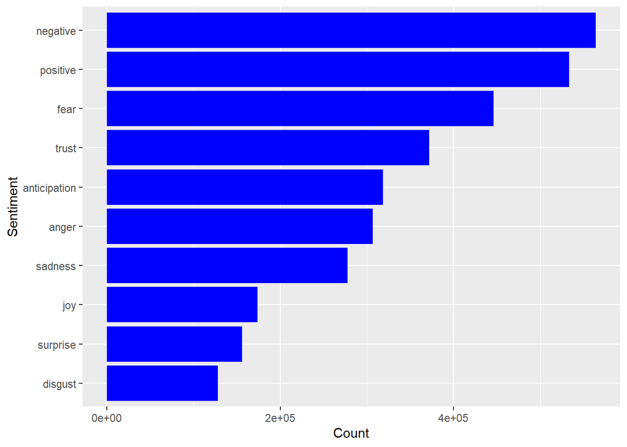

```r
ggplot(abcnews_sentiment_all) +
  geom_bar(stat = "identity", aes(x=reorder(sentiment, n), y=n), fill="blue")+
  labs(x="Sentiment", y="Count")+
  coord_flip()
```

#### Overall sentiment with “bing” lexicon

```r
# Now count the words in our data that belong to all different sentiments
abcnews_sentiment_all<- abcnews1 %>%
  inner_join(get_sentiments("bing")) %>%
  filter(!is.na(sentiment)) %>%
  count(sentiment, sort = TRUE)
abcnews_sentiment_all
```

```
## # A tibble: 2 x 2
##   sentiment      n
##   <chr>      <int>
## 1 negative  446745
## 2 positive  218246
```

#### Sentiment analysis by year

We first restructure our data with daily level, where we count the positive and negative sentiment for all news everyday. In the end, we create the column “year” so that we can further look at the sentiment for each year.

```r
# I recommend you to run these part step by step to see what each line does
abcnews_sentiment_year <- abcnews1 %>%
  inner_join(get_sentiments("bing")) %>%
  count(publish_date, sentiment) %>%
  spread(sentiment, n, fill = 0) %>%
  mutate(sentiment = positive - negative) %>%
  mutate(year= substr(publish_date, 1, 4)) %>%
  group_by(year) %>%  # these three lines create an index column for each year.
  mutate(index=row_number(year)) %>%
  ungroup()
abcnews_sentiment_year
```

```
## # A tibble: 5,422 x 6
##    publish_date negative positive sentiment year  index
##           <dbl>    <dbl>    <dbl>     <dbl> <chr> <int>
##  1     20030219       79       39       -40 2003      1
##  2     20030220      110       49       -61 2003      2
##  3     20030221      104       67       -37 2003      3
##  4     20030222       51       27       -24 2003      4
##  5     20030223       62       26       -36 2003      5
##  6     20030224      113       54       -59 2003      6
##  7     20030225      109       45       -64 2003      7
##  8     20030226      112       45       -67 2003      8
##  9     20030227       88       50       -38 2003      9
## 10     20030228       98       56       -42 2003     10
## # ... with 5,412 more rows
```

Now we can use `ggplot` to get the sentiment plot, so we can better observe how ABC News’ emotion is.

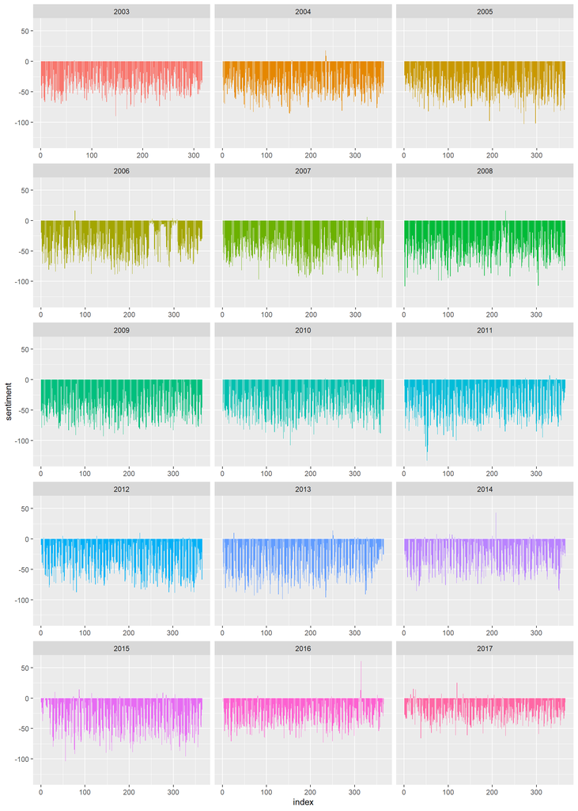

```r
ggplot(abcnews_sentiment_year, aes(index, sentiment, fill = year)) +
  geom_col(show.legend = FALSE) +
  facet_wrap(~year, ncol = 3, scales = "free_x")
```

Back to top

## Exercise – Trump Twitter data

You can use the code below to import the data. The data is also available on Blackboard. You may also get the latest version with the most recent tweets at http://www.trumptwitterarchive.com/archive.

```r
trumptwitter<- read_csv("https://www.dropbox.com/s/j0n9gu8mncmpocl/TrumpTwitter.csv?dl=1")
trumptwitter
```

```
## # A tibble: 46,608 x 7
##    source  text       created_at retweet_count favorite_count is_retweet  id_str
##    <chr>   <chr>      <chr>              <dbl>          <dbl> <lgl>        <dbl>
##  1 Twitte~ "RT @real~ 3/19/2020~         42992              0 TRUE       1.24e18
##  2 Twitte~ "https://~ 3/19/2020~         10226          42405 FALSE      1.24e18
##  3 Twitte~ "RT @FLOT~ 3/19/2020~         27302              0 TRUE       1.24e18
##  4 Twitte~ "America\~ 3/19/2020~         14988          59063 FALSE      1.24e18
##  5 Twitte~ "THANK YO~ 3/19/2020~         27241         140847 FALSE      1.24e18
##  6 Twitte~ "THANK YO~ 3/19/2020~         13910          58791 FALSE      1.24e18
##  7 Twitte~ "RT @Whit~ 3/19/2020~          6627              0 TRUE       1.24e18
##  8 Twitte~ "RT @Surg~ 3/19/2020~          5183              0 TRUE       1.24e18
##  9 Twitte~ "RT @Whit~ 3/19/2020~          9444              0 TRUE       1.24e18
## 10 Twitte~ "RT @Whit~ 3/19/2020~          6304              0 TRUE       1.24e18
## # ... with 46,598 more rows
```

```r
# convert to Corpus
text<- Corpus(VectorSource(trumptwitter$text))
# basic cleaning
#text<- str_replace_all(text,"[^[:graph:]]", " ")
text<- tm_map(text, function(x) iconv(enc2utf8(x), sub = "byte"))
text<- tm_map(text, content_transformer(tolower))
text<- tm_map(text, removePunctuation)
text<- tm_map(text, removeWords, stopwords("english"))
# word cloud
wordcloud(text, max.words = 100, random.order = FALSE, rot.per=0.3, colors=brewer.pal(8, "Dark2"))

# sentiment analysis
trumptwitter1<- trumptwitter %>% unnest_tokens(word, text)
trumptwitter1

# overall sentiment
trumptwitter_sentiment_all<- trumptwitter1 %>%
  inner_join(get_sentiments("nrc")) %>%
  filter(!is.na(sentiment)) %>%
  count(sentiment, sort = TRUE)
trumptwitter_sentiment_all

ggplot(trumptwitter_sentiment_all) +
  geom_bar(stat = "identity", aes(x=reorder(sentiment,n), y=n), fill="blue")+
  labs(x="Sentiment", y="Count")+
  coord_flip()

# overall sentiment by presidential election period
trumptwitter_sentiment_3period<- trumptwitter1 %>%
  inner_join(get_sentiments("bing")) %>%
  filter(!is.na(sentiment)) %>%
  separate(created_at, into = c("date", "time"), sep=" ") %>%
  separate(date, into = c("month", "day", "year"), sep = "/", remove = F)%>%
  filter(!is.na(year)) %>%
  mutate(year=as.numeric(year), stage=cut(year, breaks = c(-Inf, 2014, 2016, Inf), include.lowest = T, labels = c("Before", "Campaign", "After")))%>%
  group_by(stage, sentiment)%>%
  summarise(n=n())
trumptwitter_sentiment_3period

ggplot(trumptwitter_sentiment_3period) +
  geom_bar(stat = "identity", aes(x=stage, y=n, fill=sentiment), position = "dodge")+
  labs(x="Election stage", y="Count")


# sentiment by hour
trumptwitter_sentiment <- trumptwitter1 %>%
  separate(created_at, into = c("date", "time"), sep=" ") %>%
  separate(date, into = c("month", "day", "year"), sep = "/", remove = F)%>%
  separate(time, into = c("hour", "second"), sep=":") %>%
  inner_join(get_sentiments("bing"))

trumptwitter_sentiment1 <- trumptwitter_sentiment %>%
  mutate(year=as.numeric(year), stage=cut(year, breaks = c(-Inf, 2014, 2016, Inf), include.lowest = T, labels = c("Before", "Campaign", "After")))%>%
  filter(!is.na(year)) %>%
  group_by(stage, hour, sentiment)%>%
  summarise(n=n())%>%
  spread(sentiment, n, fill = 0) %>%
  mutate(sentiment = positive - negative) %>%
  ungroup()

ggplot(trumptwitter_sentiment1) +
  geom_bar(stat = "identity", aes(x=as.numeric(hour), y=sentiment), fill="blue")+
  labs(x="Hour during a day", y="Score")+
  facet_wrap(~stage, nrow = 3, scales = "free_x")
```

Back to top